# Introducción a R y Analítica de Datos

# Clustering

La agrupación en clústeres es una forma de aprendizaje no supervisado porque simplemente intentamos encontrar una estructura dentro de un conjunto de datos en lugar de predecir el valor de alguna variable de respuesta. Es normal utilizar todos los datos sin hacer particionamiento, ya que en este caso es clusterizacion no supervisada.

```r
library(dplyr)
data = read.csv("https://raw.githubusercontent.com/krishnaik06/DBSCAN-Algorithm/master/Mall_Customers.csv")

head(data)
```

```
##   CustomerID  Genre Age Annual.Income..k.. Spending.Score..1.100.
## 1          1   Male  19                 15                     39
## 2          2   Male  21                 15                     81
## 3          3 Female  20                 16                      6
## 4          4 Female  23                 16                     77
## 5          5 Female  31                 17                     40
## 6          6 Female  22                 17                     76
```

```r
data <- data %>% rename("AnualIncome" = "Annual.Income..k..", "SpendingScore" = "Spending.Score..1.100.")

head(data)
```

```
##   CustomerID  Genre Age AnualIncome SpendingScore
## 1          1   Male  19          15            39
## 2          2   Male  21          15            81
## 3          3 Female  20          16             6
## 4          4 Female  23          16            77
## 5          5 Female  31          17            40
## 6          6 Female  22          17            76
```

## Removiendo nulos

```r
data <- na.omit(data)
head(data)
```

```
##   CustomerID  Genre Age AnualIncome SpendingScore
## 1          1   Male  19          15            39
## 2          2   Male  21          15            81
## 3          3 Female  20          16             6
## 4          4 Female  23          16            77
## 5          5 Female  31          17            40
## 6          6 Female  22          17            76
```

## Escalado normal

```r
library(dplyr)
data.complete <- data %>% select_if(is.numeric)

data.complete <- scale(data.complete)

head(data.complete)
```

```
##   CustomerID        Age AnualIncome SpendingScore
## 1  -1.719098 -1.4210029   -1.734646    -0.4337131
## 2  -1.701821 -1.2778288   -1.734646     1.1927111
## 3  -1.684543 -1.3494159   -1.696572    -1.7116178
## 4  -1.667266 -1.1346547   -1.696572     1.0378135
## 5  -1.649989 -0.5619583   -1.658498    -0.3949887
## 6  -1.632711 -1.2062418   -1.658498     0.9990891
```

## Clustering

Para realizar el agrupamiento de k-means en R, podemos usar la función kmeans() incorporada, que usa la siguiente sintaxis:

kmeans(datos, centros, nstart)

dónde:

datos: Nombre del conjunto de datos. centros: el número de grupos, denotados k . nstart: el número de configuraciones iniciales. Debido a que es posible que diferentes clústeres de inicio inicial puedan generar resultados diferentes, se recomienda utilizar varias configuraciones iniciales diferentes. El algoritmo de k-medias encontrará las configuraciones iniciales que conducen a la variación más pequeña dentro del grupo.

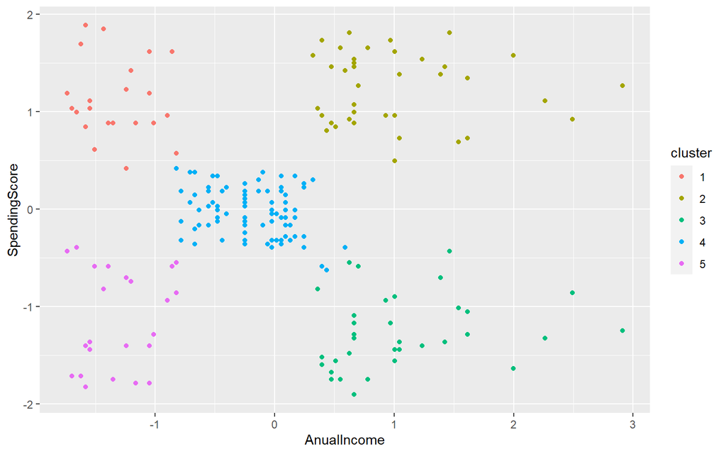

```r
library(plotly)
library(ggplot2)

data.complete <- data.frame(data.complete)
data.complete <- data.complete[,3:4]

km.data <- kmeans(data.complete, centers = 5)
data.complete <- cbind(data.complete, cluster=km.data$cluster)

data.complete$cluster <- as.factor(data.complete$cluster)

ggplot(data.complete, aes(x=AnualIncome, y=SpendingScore)) + geom_point(aes(colour=cluster))
```

## Optimizacion de clusters

Por lo general, cuando creamos este tipo de gráfico, buscamos un “codo” donde la suma de los cuadrados comienza a “doblarse” o nivelarse. Este suele ser el número óptimo de clústeres. Para esto podemos usar la técnica de elbow.

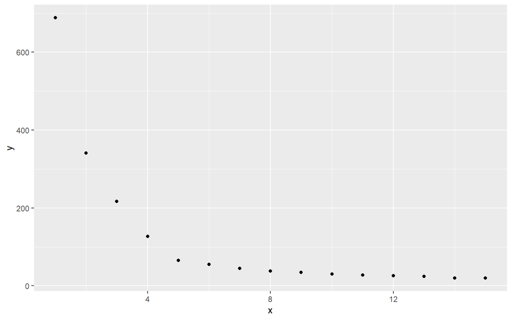

```r
wss <- 0
for (i in 1:15) {
  km.data <- kmeans(data.complete, centers = i, nstart=25, iter.max = 50)
  wss[i] <- km.data$tot.withinss
}

efectiveness <- data.frame(x = 1:15, y = wss)

ggplot(efectiveness, aes(x=x, y=y)) + geom_point()
```

Logramos visualizar el resultado y asociamos el customerID a cada uno de los clientes

```r
data.complete$customer_id <- data$CustomerID

head(data.complete)
```

```
##   AnualIncome SpendingScore cluster customer_id
## 1   -1.734646    -0.4337131       5           1
## 2   -1.734646     1.1927111       1           2
## 3   -1.696572    -1.7116178       5           3
## 4   -1.696572     1.0378135       1           4
## 5   -1.658498    -0.3949887       5           5
## 6   -1.658498     0.9990891       1           6
```

# Regresion lineal

Usaremos el conjunto de datos del dataset de R llamado mtcars, con el objetivo de estimar o predecir las millas por galón(mpg) en función a las variables continuas que tiene el dataset. Las variables a utilizar son:

```
Mpg: Millas por galón

Disp: Desplazamiento

Hp: Potencia Bruta

Drat: engranaje del eje trasero

Wt: Peso en libras

Qsec: 1/4 de milla de tiempo
```

```r
library(caret)
datos <- mtcars

index <- createDataPartition(datos$mpg, times = 1, p = 0.8, list = FALSE)

train.data <- datos[index, ]
test.data <- datos[-index,]

head(train.data)
```

```
##                    mpg cyl disp  hp drat    wt  qsec vs am gear carb
## Mazda RX4         21.0   6  160 110 3.90 2.620 16.46  0  1    4    4
## Mazda RX4 Wag     21.0   6  160 110 3.90 2.875 17.02  0  1    4    4
## Datsun 710        22.8   4  108  93 3.85 2.320 18.61  1  1    4    1
## Hornet 4 Drive    21.4   6  258 110 3.08 3.215 19.44  1  0    3    1
## Hornet Sportabout 18.7   8  360 175 3.15 3.440 17.02  0  0    3    2
## Valiant           18.1   6  225 105 2.76 3.460 20.22  1  0    3    1
```

## Realizamos correlaciones

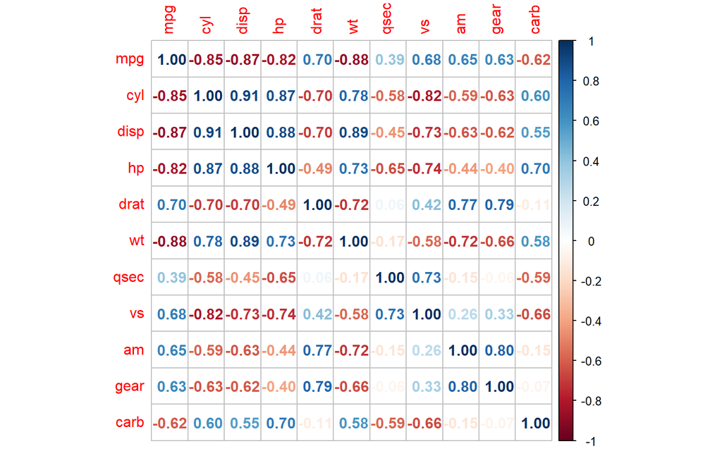

```r
library(corrplot)
matriz <- train.data %>% select_if(is.numeric)
correlacion <- round(cor(matriz), 2) # Sirve para hacer redondeos de datos

corrplot(correlacion, method="number")
```

## Aplicamos la regresion

```r
model.linear <- lm(mpg ~ disp + hp + drat + wt, data = train.data)
summary(model.linear)
```

```
##
## Call:
## lm(formula = mpg ~ disp + hp + drat + wt, data = train.data)
##
## Residuals:
##     Min      1Q  Median      3Q     Max
## -3.5536 -1.3376 -0.4881  0.7376  5.9374
##
## Coefficients:
##             Estimate Std. Error t value Pr(>|t|)
## (Intercept) 27.41441    5.94199   4.614 0.000122 ***
## disp         0.01051    0.01262   0.833 0.413533
## hp          -0.04835    0.01695  -2.852 0.009028 **
## drat         2.12942    1.26807   1.679 0.106637
## wt          -3.29306    1.04483  -3.152 0.004464 **
## ---
## Signif. codes:  0 '***' 0.001 '**' 0.01 '*' 0.05 '.' 0.1 ' ' 1
##
## Residual standard error: 2.386 on 23 degrees of freedom
## Multiple R-squared:  0.8611, Adjusted R-squared:  0.8369
## F-statistic: 35.63 on 4 and 23 DF,  p-value: 1.514e-09
```

Obtenemos un resultado cercano a 0.83 en el R-squared que es nuestro indicador de efectividad para la regresion.

## Identificar los mejores predictores

```r
step(model.linear, direction = "both", trace = 0)
```

```
##
## Call:
## lm(formula = mpg ~ hp + drat + wt, data = train.data)
##
## Coefficients:
## (Intercept)           hp         drat           wt
##    28.08239     -0.03761      1.73009     -2.75859
```

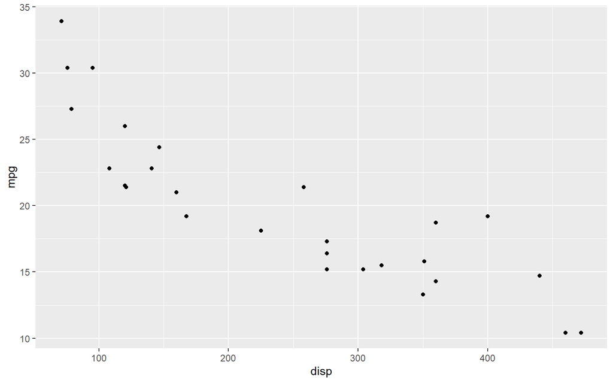

```r
ggplot(train.data, aes(x = disp, y = mpg)) + geom_point()
```

## Generando un modelo con los mejores predictores

```r
model.linear.best <- lm(mpg ~ hp + wt, data = train.data)
summary(model.linear)
```

```
##
## Call:
## lm(formula = mpg ~ disp + hp + drat + wt, data = train.data)
##
## Residuals:
##     Min      1Q  Median      3Q     Max
## -3.5536 -1.3376 -0.4881  0.7376  5.9374
##
## Coefficients:
##             Estimate Std. Error t value Pr(>|t|)
## (Intercept) 27.41441    5.94199   4.614 0.000122 ***
## disp         0.01051    0.01262   0.833 0.413533
## hp          -0.04835    0.01695  -2.852 0.009028 **
## drat         2.12942    1.26807   1.679 0.106637
## wt          -3.29306    1.04483  -3.152 0.004464 **
## ---
## Signif. codes:  0 '***' 0.001 '**' 0.01 '*' 0.05 '.' 0.1 ' ' 1
##
## Residual standard error: 2.386 on 23 degrees of freedom
## Multiple R-squared:  0.8611, Adjusted R-squared:  0.8369
## F-statistic: 35.63 on 4 and 23 DF,  p-value: 1.514e-09
```

## Con datos de prueba

```r
# install.packages(Metrics)
library(Metrics)
predicted <- predict(model.linear, newdata = test.data)
predicted
```

```
##     Merc 280C      Fiat 128  Ferrari Dino Maserati Bora
##      20.24859      26.49405      19.06462      10.16409
```

```r
# Efectividad con los datos de prueba
rmse(test.data$mpg, predicted)
```

```
## [1] 4.020744
```

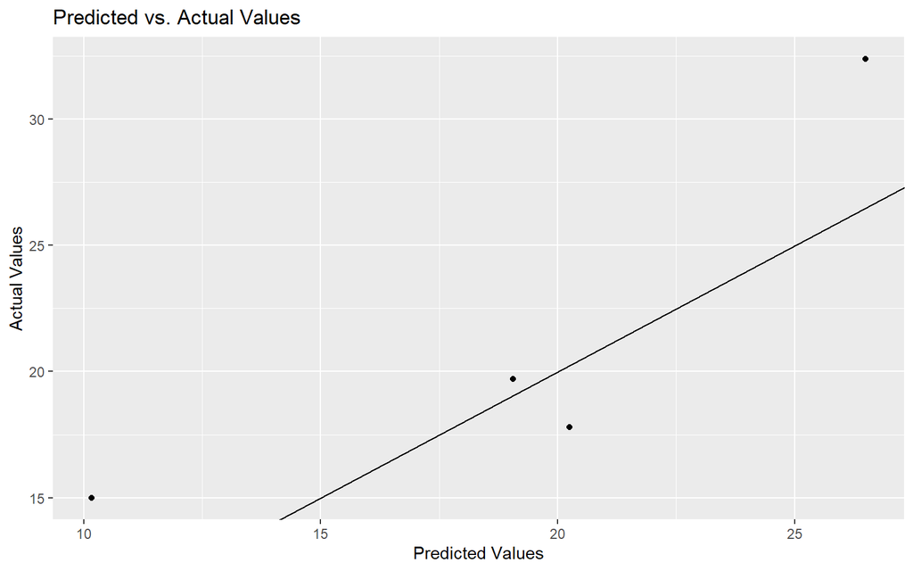

```r
#plot predicted vs. actual values
ggplot(test.data, aes(x = predicted, y = mpg)) +
  geom_point() +
  geom_abline(intercept=0, slope=1) +
  labs(x='Predicted Values', y='Actual Values', title='Predicted vs. Actual Values')
```

## Predecir con nuevos datos

```r
predicted <- predict(model.linear.best, newdata = data.frame(hp = 100, wt = 3.570))
predicted
```

```
##        1
## 20.36527
```